# Exploring Healthy Ride Pittsburgh Data With R

Conor Tompkins

2017-10-18

Healthy Ride is a bike rental service in Pittsburgh. The [WPRDC](http://www.wprdc.org/) hosts [data about their service](https://data.wprdc.org/organization/about/healthy-ride). We can use the data to get an idea of how Pittsburghers use the service.

In my analysis, I use R and tidyverse, lubridate, and some other packages.

First, load the packages we will be using:

```r
library(tidyverse)
library(lubridate)
library(viridis)
library(scales)
```

Set the theme to format the plots:

```r
theme_set(theme_bw())
```

Load the data from the WPRDC (hosted on [my GitHub page](https://github.com/conorotompkins)):

```r
data <- read_csv("https://raw.githubusercontent.com/conorotompkins/healthy_ride/master/data/data.csv")
```

First, we need to format the data and the column names to make them more useful for analysis:

```r
colnames(data) <- tolower(colnames(data))
colnames(data) <- gsub(" ", "_", colnames(data))
```

Change to snake_case and drop old columns:

```r
data_long <- data %>%
  rename(start_date_time = starttime,
         stop_date_time = stoptime)
```

Make the dataframe longer:

```r
data_long <- data_long %>%
  gather(date_time_type, date_time, c(start_date_time, stop_date_time)) %>%
  select(date_time_type, date_time, everything())
```

Format the date and time columns using lubridate:

```r
data_long <- data_long %>%
  mutate(date_time_2 = date_time) %>%
  separate(date_time, " ", into = c("date", "time")) %>%
  mutate(id = row_number(),
         date = mdy(date),
         year = year(date),
         month = month(date, label = TRUE),
         week = week(date),
         time = hm(time),
         hour = hour(time),
         wday = wday(date, label = TRUE),
         is_weekday = ifelse(wday %in% c("Mon", "Tues", "Wed", "Thurs", "Fri"), "weekday", "weekend"),
         yday = yday(date),
         mday = mday(date)) %>%
  mutate(trip_duration = (tripduration / 60) / 60)
```

Make the dataframe longer:

```r
data_long <- data_long %>%
  gather(station_id_type, station_id, c(from_station_id, to_station_id)) %>%
  gather(station_name_type, station_name, c(from_station_name, to_station_name))
```

Reorder the columns:

```r
data_long <- data_long %>%
  select(date_time_type,
         is_weekday,
         date,
         year,
         month,
         time,
         hour,
         wday,
         yday,
         mday,
         date_time_2,
         station_id_type,
         station_id,
         station_name_type,
         station_name,
         everything())
```

Let’s look at how the data look:

```r
data_long
```

```
## # A tibble: 1,364,248 x 22
##     date_time_type is_weekday       date  year month         time  hour
##              <chr>      <chr>     <date> <dbl> <ord> <S4: Period> <dbl>
##  1 start_date_time    weekend 2015-05-31  2015   May    6H 54M 0S     6
##  2 start_date_time    weekend 2015-05-31  2015   May    6H 57M 0S     6
##  3 start_date_time    weekend 2015-05-31  2015   May    6H 58M 0S     6
##  4 start_date_time    weekend 2015-05-31  2015   May     7H 8M 0S     7
##  5 start_date_time    weekend 2015-05-31  2015   May    7H 15M 0S     7
##  6 start_date_time    weekend 2015-05-31  2015   May    7H 16M 0S     7
##  7 start_date_time    weekend 2015-05-31  2015   May    7H 18M 0S     7
##  8 start_date_time    weekend 2015-05-31  2015   May    7H 18M 0S     7
##  9 start_date_time    weekend 2015-05-31  2015   May    7H 20M 0S     7
## 10 start_date_time    weekend 2015-05-31  2015   May    7H 25M 0S     7
## # ... with 1,364,238 more rows, and 15 more variables: wday <ord>,
## #   yday <dbl>, mday <int>, date_time_2 <chr>, station_id_type <chr>,
## #   station_id <int>, station_name_type <chr>, station_name <chr>,
## #   trip_id <int>, bikeid <int>, tripduration <int>, usertype <chr>,
## #   id <int>, week <dbl>, trip_duration <dbl>
```

How has the use of the service trended in the long term?

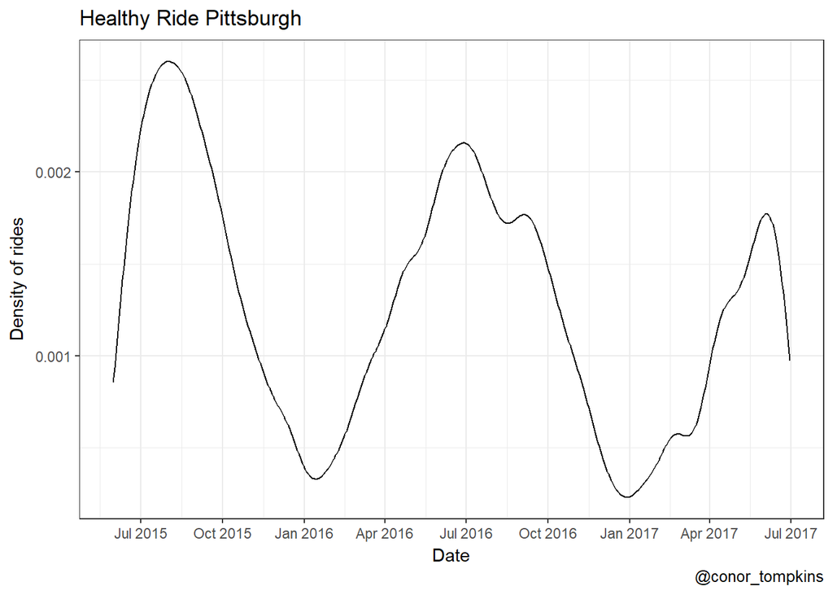

```r
data_long %>%
  filter(date_time_type == "start_date_time") %>%
  ggplot(aes(date)) +
  geom_freqpoly(stat = "density") +
  scale_x_date(date_labels = "%b %Y",
               date_breaks = "3 months") +
  labs(title = "Healthy Ride Pittsburgh",
       x = "Date",
       y = "Density of rides",
       caption = "@conor_tompkins")
```

A cumulative look at the number of rides:

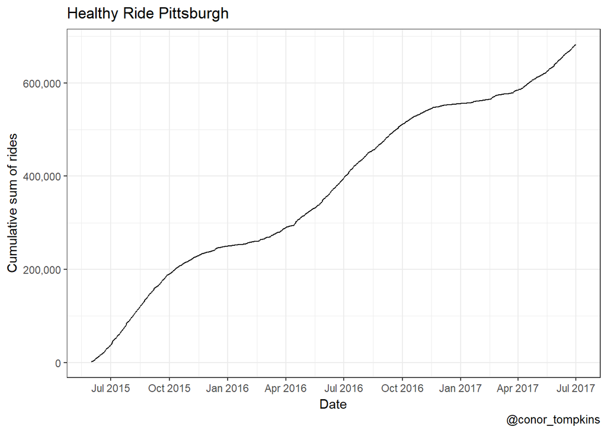

```r
data_long %>%
  filter(station_name_type == "from_station_name") %>%
  arrange(date) %>%
  count(date) %>%
  mutate(cum_sum = cumsum(n)) %>%
  ggplot(aes(date, cum_sum)) +
  geom_line() +
    scale_x_date(date_labels = "%b %Y",
               date_breaks = "3 months") +
  scale_y_continuous(labels = scales::comma) +
  labs(title = "Healthy Ride Pittsburgh",
      x = "Date",
      y = "Cumulative sum of rides",
      caption = "@conor_tompkins")
```

A yearly look at the data shows that ridership has dropped off in 2017:

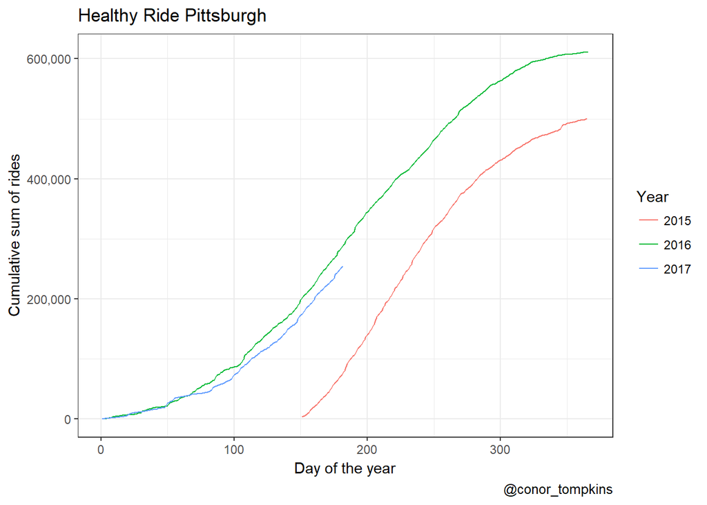

```r
data_long %>%
  select(year, yday) %>%
  mutate(year = as.factor(year)) %>%
  group_by(year, yday) %>%
  count() %>%
  ungroup() %>%
  group_by(year) %>%
  mutate(cum_sum = cumsum(n)) %>%
  ggplot(aes(yday, cum_sum,
             color = year,
             group = year)) +
  geom_line() +
  scale_y_continuous(labels = scales::comma) +
  guides(color = guide_legend(title = "Year")) +
  labs(title = "Healthy Ride Pittsburgh",
      x = "Day of the year",
      y = "Cumulative sum of rides",
      caption = "@conor_tompkins")
```

How are the number of rides distributed throughout the day?

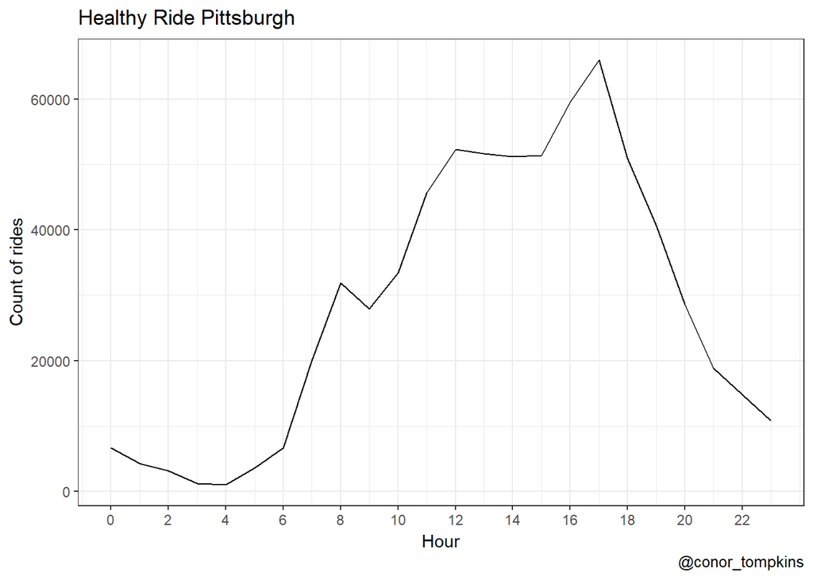

```r
data_long %>%
  filter(date_time_type == "start_date_time") %>%
  ggplot(aes(hour)) +
  geom_freqpoly(stat = "count") +
  scale_x_continuous(breaks = seq(0, 23, by = 2)) +
  labs(title = "Healthy Ride Pittsburgh",
      x = "Hour",
      y = "Count of rides",
      caption = "@conor_tompkins")
```

Ridership peaks during evening rush-hour.

The trend is different for weekdays vs. weekends:

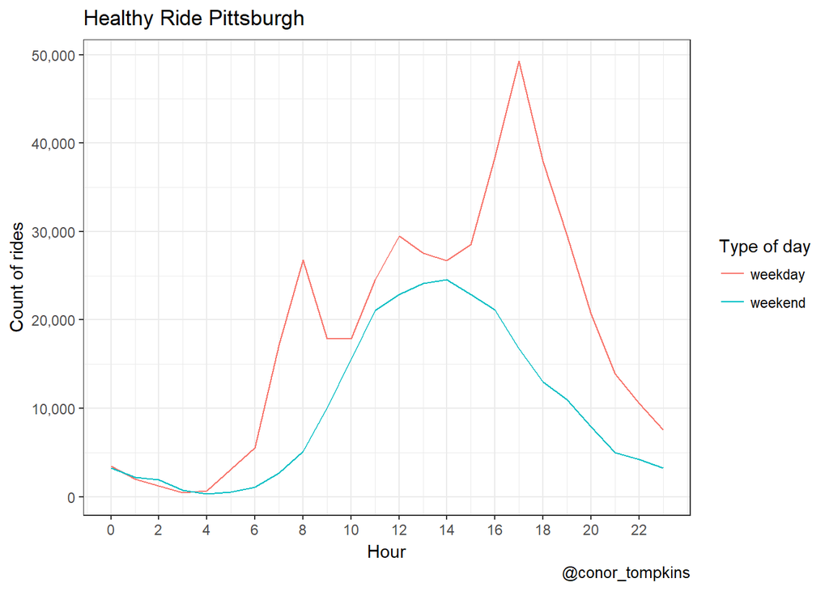

```r
data_long %>%
  filter(date_time_type == "start_date_time") %>%
  ggplot(aes(hour, color = is_weekday)) +
  geom_freqpoly(stat = "count") +
  scale_x_continuous(breaks = seq(0, 23, by = 2)) +
  scale_y_continuous(labels = scales::comma) +
  guides(color = guide_legend(title = "Type of day")) +
  labs(title = "Healthy Ride Pittsburgh",
    x = "Hour",
    y = "Count of rides",
    caption = "@conor_tompkins")
```

Breaking it down by weekday, people appear to take rides during their lunch break on Fridays. Saturdays at around 1PM see peak usage.

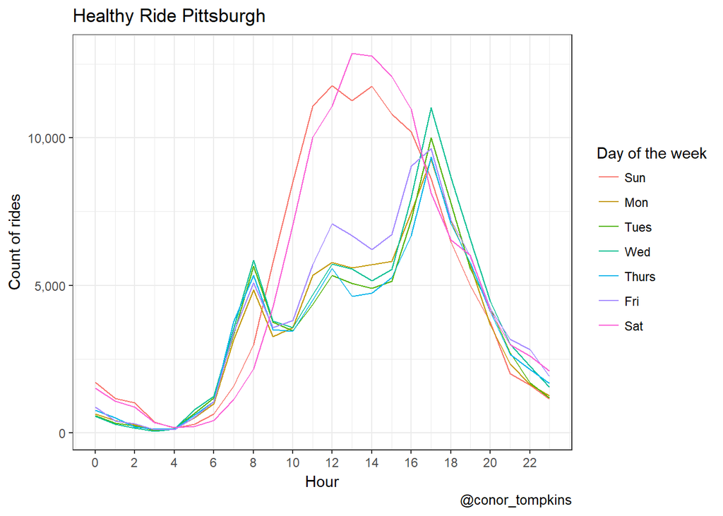

```r
data_long %>%
  filter(date_time_type == "start_date_time") %>%
  ggplot(aes(hour, color = wday)) +
  geom_freqpoly(stat = "count") +
  scale_x_continuous(breaks = seq(0, 23, by = 2)) +
  scale_y_continuous(labels = scales::comma) +
  guides(color = guide_legend(title = "Day of the week")) +
  labs(title = "Healthy Ride Pittsburgh",
    x = "Hour",
    y = "Count of rides",
    caption = "@conor_tompkins")
```

We can also zoom out to look at the data by year, month, day of the month, and hour. First, create a new dataframe and use complete() and replace_na() to fill out the dataframe:

```r
#this make take a minute to run
df_tile <- data_long %>%
  select(year, month, mday, hour) %>%
  group_by(year, month, mday, hour) %>%
  summarize(n = n()) %>%
  complete(year, month, mday = 1:31, hour = 0:23) %>%
  replace_na(replace = list(n = 0))
```

This code creates the tile plot:

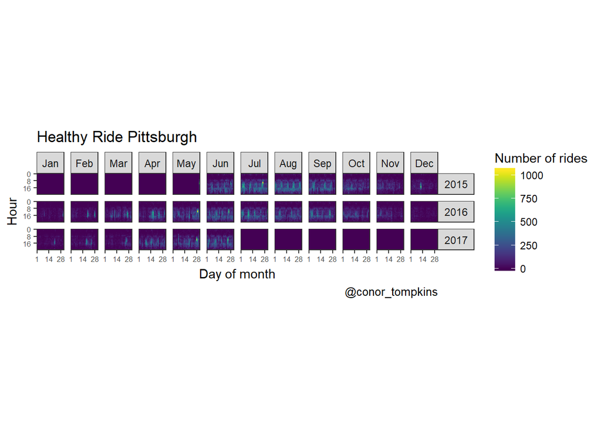

```r
#this make take a minute to run
df_tile %>%
  ggplot(aes(mday, hour, fill = n)) +
  geom_tile() +
  scale_y_reverse(expand = c(0,0),
                  breaks = c(0, 8, 16)) +
  scale_x_continuous(expand = c(0,0),
                     breaks = c(1, 14, 28)) +
  facet_grid(year ~ month) +
  coord_equal() +
  scale_fill_viridis() +
  guides(fill = guide_colorbar(title = "Number of rides")) +
  labs(title = "Healthy Ride Pittsburgh",
    x = "Day of month",
    y = "Hour",
    caption = "@conor_tompkins") +
  theme(strip.text.y = element_text(angle = 0),
        axis.text = element_text(size = 6))
```

We can also look at the the sum of hours biked across the same date and time variables:

```r
#this make take a minute to run
df_tile2 <- data_long %>%
  select(year, month, mday, hour, trip_duration) %>%
  group_by(year, month, mday, hour) %>%
  summarize(trip_duration_sum = sum(trip_duration)) %>%
  complete(year, month, mday = 1:31, hour = 0:23) %>%
  replace_na(replace = list(trip_duration_sum = 0))
```

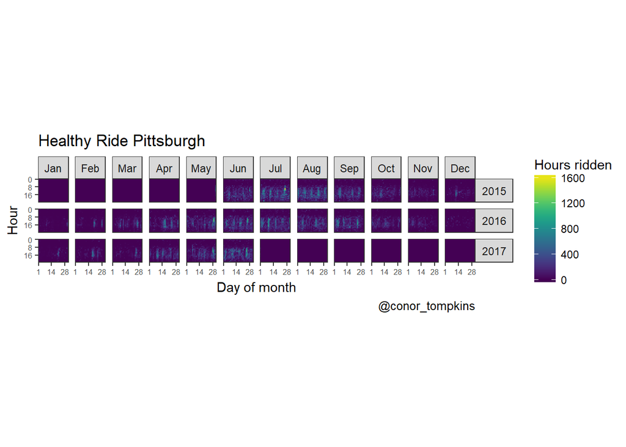

```r
#this make take a minute to run
df_tile2 %>%
  ggplot(aes(mday, hour, fill = trip_duration_sum)) +
  geom_tile() +
  scale_y_reverse(expand = c(0,0),
                  breaks = c(0, 8, 16)) +
  scale_x_continuous(expand = c(0,0),
                     breaks = c(1, 14, 28)) +
  facet_grid(year ~ month) +
  coord_equal() +
  scale_fill_viridis() +
  guides(fill = guide_colorbar(title = "Hours ridden")) +
  labs(title = "Healthy Ride Pittsburgh",
    x = "Day of month",
    y = "Hour",
    caption = "@conor_tompkins") +
  theme(strip.text.y = element_text(angle = 0),
        axis.text = element_text(size = 6))
```